# Article data analysis

Håkon Kaspersen

22.01.2019

# 1 Background

## 1.1 Aims

- Identify potential differences in resistance mechanisms between wild- and production animals.
- Identify potential clones which are species specific.
- Characterize resistance mechanisms in QREC from Norwegian wild- and production animals.
- Identify “main culprit” mechanisms that infer high MIC values for CIP and/or NAL.
- Characterize the population structure of QREC from selected animal species.

## 1.2 Isolates and Methods

To identify resistance genes of interest, the sequences were run through the program “Antimicrobial Resistance Identification By Assembly” (ARIBA), which is included in the Bifrost Pipeline. Acquired resistance genes were detected by the use of the ResFinder database, while mutations in intrinsic genes related to quinolone resistance was identified with the MegaRes database. Sequence types was also identified by ARIBA, using the Wirth et al. scheme (*E. coli* #1).

Results from various analyses are listed below.

```r
# Libraries
if (!require("pacman")) install.packages("pacman")
pacman::p_load(dplyr, ggplot2, tidyr, cowplot, viridis, forcats, radiant.data, purrr, phangorn, gridExtra, ggtree, htmlTable, ape, cluster, tibble)
```

# 2 Sequence data

## 2.1 Distribution of number of reads per sequencer

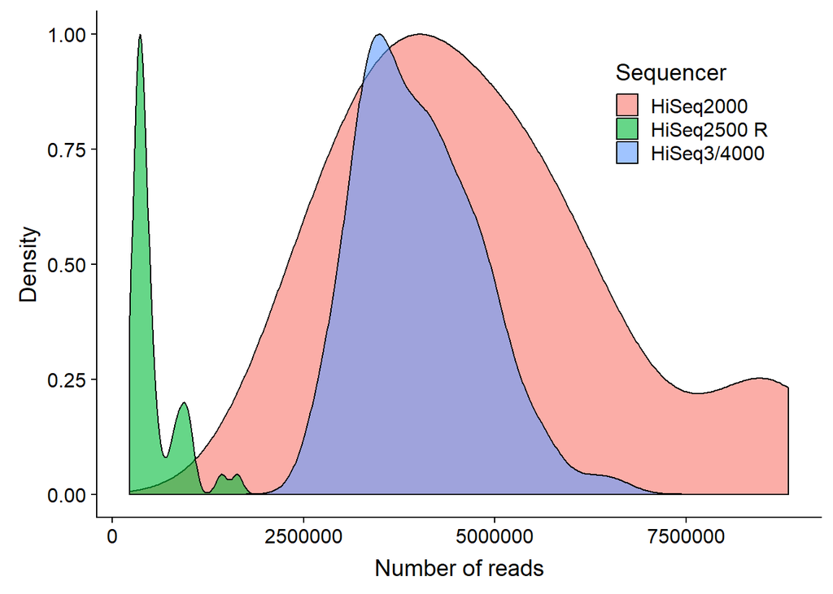

```r
sequence_data <- no_of_reads %>%
  left_join(isolate_data, by = "id") %>%
  mutate_at(vars(`R1-1`,`R2-1`,`R1-2`,`R2-2`),
            funs(as.numeric(as.character(.))))

ggplot(sequence_data, aes(as.numeric(`R1-1`)))+
  geom_density(aes(fill = sequencer,
                   y = ..scaled..),
               alpha = 0.6)+
  labs(x = "Number of reads",
       y = "Density",
       fill = "Sequencer")+
  theme(legend.position = c(0.7, 0.8))
```

## 2.2 Distribution of number of reads per library prep type

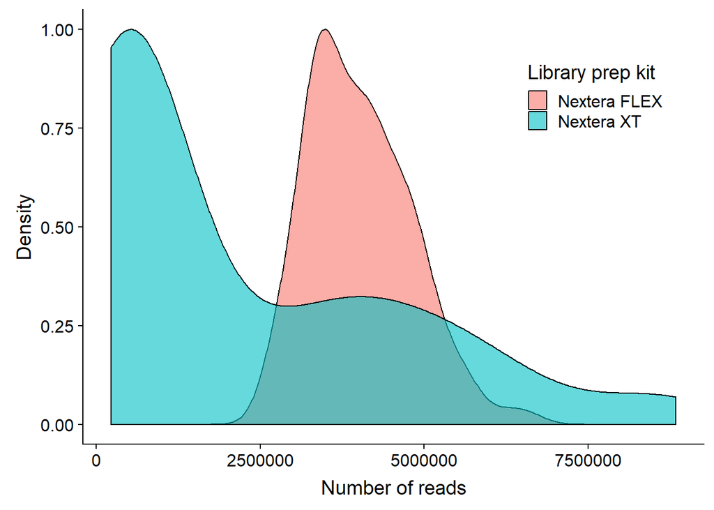

```r
ggplot(sequence_data, aes(as.numeric(`R1-1`)))+
  geom_density(aes(fill = libprep,
                   y = ..scaled..),
               alpha = 0.6)+
  labs(x = "Number of reads",
       y = "Density",
       fill = "Library prep kit")+
  theme(legend.position = c(0.7, 0.8))
```

## 2.3 Distribution of number of reads per animal species

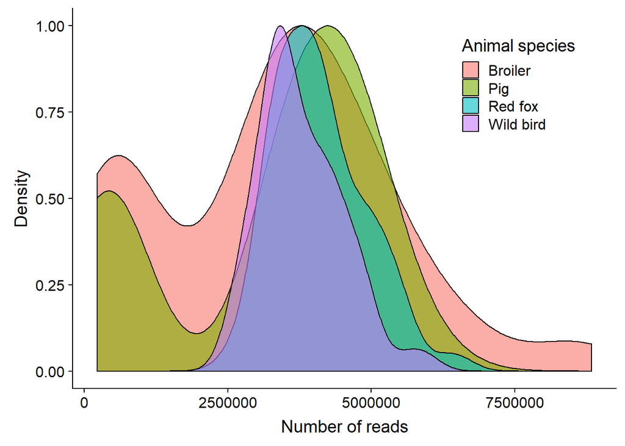

```r
ggplot(sequence_data, aes(as.numeric(`R1-1`)))+
  geom_density(aes(fill = species,
                   y = ..scaled..),
               alpha = 0.6)+
  labs(x = "Number of reads",
       y = "Density",
       fill = "Animal species")+
  theme(legend.position = c(0.7, 0.8))
```

# 3 Tables

## 3.1 Isolate data

```r
isolate_data_complete <- isolate_data %>%
  left_join(no_of_reads, by = "id")

isolate_data_complete
```

| id | species | method | qubit | X260.280 | X260.230 | WGS | sequencer | libprep | read_length | group | R1-1 | R2-1 | R1-2 | R2-2 |
| --- | --- | --- | --- | --- | --- | --- | --- | --- | --- | --- | --- | --- | --- | --- |
| 2006-01-2821-1-T | Broiler | T | 129.00 | 1.838 | 2.094 | HK&SSM | HiSeq3/4000 | Nextera FLEX | 150 | A | 3476176 | 3476176 | NA | NA |
| 2009-01-1690-1-T | Broiler | T | 224.00 | 1.854 | 2.113 | HK&SSM | HiSeq3/4000 | Nextera FLEX | 150 | A | 3593612 | 3593612 | NA | NA |
| 2009-01-413-1-T | Broiler | T | 130.00 | 1.842 | 2.082 | HK&SSM | HiSeq3/4000 | Nextera FLEX | 150 | A | 2865984 | 2865984 | NA | NA |
| 2009-01-4618-2-T | Broiler | T | 78.80 | 1.825 | 1.749 | HK&SSM | HiSeq3/4000 | Nextera FLEX | 150 | A | 3174672 | 3174672 | NA | NA |
| 2009-01-551-1-T | Broiler | T | 192.00 | 1.848 | 1.874 | HK&SSM | HiSeq3/4000 | Nextera FLEX | 150 | A | 4231861 | 4231861 | NA | NA |
| 2011-01-1544-2-T | Broiler | T | 174.00 | 1.838 | 2.141 | HK&SSM | HiSeq3/4000 | Nextera FLEX | 150 | A | 2793502 | 2793502 | NA | NA |
| 2011-01-3460-5-T | Broiler | T | 73.20 | 1.822 | 1.900 | HK&SSM | HiSeq3/4000 | Nextera FLEX | 150 | A | 3102290 | 3102290 | NA | NA |
| 2011-01-6927-5-T | Broiler | T | 82.80 | 1.819 | 1.859 | HK&SSM | HiSeq3/4000 | Nextera FLEX | 150 | A | 2765836 | 2765836 | NA | NA |
| 2012-01-838-6-T | Broiler | T | 168.00 | 1.849 | 2.039 | HK&SSM | HiSeq3/4000 | Nextera FLEX | 150 | A | 3518806 | 3518806 | NA | NA |
| 2013-01-2024-1-T | Broiler | T | 192.00 | 1.854 | 2.096 | HK&SSM | HiSeq3/4000 | Nextera FLEX | 150 | A | 3269490 | 3269490 | NA | NA |

[output cut: 270 more lines]

## 3.2 List of genes of interest

This table lists all the genes of interest in this study, some information about them, and their accession number(s).

```r
acquired_ref_names <- acquired_data$ref_name
acquired_ref <- c()

for (i in ac_genes) {
  for (j in acquired_ref_names) {
    if (grepl(i,j, ignore.case = T) == TRUE) {
      acquired_ref <- c(acquired_ref, j)
    }
  }
}

acquired_ref <- unique(acquired_ref)

acquired_ref_genes <- acquired_data %>%
  mutate(test = duplicated(ref_name),
         gene = case_when(grepl("qnra1", ref_name, ignore.case = T) == TRUE ~ "qnrA1",
                          grepl("qnrb19", ref_name, ignore.case = T) == TRUE ~ "qnrB19",
                          grepl("qnrb6", ref_name, ignore.case = T) == TRUE ~ "qnrB6",
                          grepl("qnrb60", ref_name, ignore.case = T) == TRUE ~ "qnrB60",
                          grepl("qnrs1", ref_name, ignore.case = T) == TRUE ~ "qnrS1",
                          grepl("qnrs2", ref_name, ignore.case = T) == TRUE ~ "qnrS2",
                          grepl("qnrs4", ref_name, ignore.case = T) == TRUE ~ "qnrs4",
                          grepl("qnrs9", ref_name, ignore.case = T) == TRUE ~ "qnrS9",
                          grepl("qep", ref_name, ignore.case = T) == TRUE ~ "qepA")) %>%
  filter(test == FALSE,
         ref_name %in% acquired_ref_names) %>%
  select(ref_name, gene) %>%
  mutate(compl = complete.cases(.)) %>%
  filter(compl == TRUE) %>%
  mutate(ref_name2 = sub(".+_(.*?)", "\\1", ref_name)) %>%
  group_by(gene) %>%
  summarise_all(funs(func_paste)) %>%
  select(gene, ref_name2) %>%
  rename("Accession number(s)" = ref_name2,
         "Gene" = gene) %>%
  mutate(Description = "Quinolone resistance protein, plasmid mediated, decreases susceptibility of quinolones",
         Type = "Acquired")

df_ref_names <- mut_data$cluster
ref_names <- c()

for (i in mut_genes) {
  for (j in df_ref_names) {
    if (grepl(i,j, ignore.case = T) == TRUE) {
      ref_names <- c(ref_names, j)
    }
  }
}

ref_names <- unique(ref_names)

intrinsic_ref_genes <- mut_data %>%
  mutate(test = duplicated(cluster),
         gene = case_when(grepl("gyra", cluster, ignore.case = T) == TRUE ~ "gyrA",
                          grepl("gyrb", cluster, ignore.case = T) == TRUE ~ "gyrB",
                          grepl("parc", cluster, ignore.case = T) == TRUE ~ "parC",
                          grepl("pare", cluster, ignore.case = T) == TRUE ~ "parE",
                          grepl("soxR", cluster, ignore.case = T) == TRUE ~ "soxR",
                          grepl("marR", cluster, ignore.case = T) == TRUE ~ "marR",
                          grepl("mara", cluster, ignore.case = T) == TRUE ~ "marA",
                          grepl("tolc", cluster, ignore.case = T) == TRUE ~ "tolC",
                          grepl("acrr", ref_name, ignore.case = T) == TRUE ~ "acrR",
                          grepl("acrb", ref_name, ignore.case = T) == TRUE ~ "acrB",
                          grepl("mdfa", ref_name, ignore.case = T) == TRUE ~ "mdfA",
                          grepl("rpob", ref_name, ignore.case = T) == TRUE ~ "rpoB")) %>%
  filter(test == FALSE,
         cluster %in% ref_names) %>%
  select(ref_name, gene, free_text) %>%
  mutate(ref_name2 = sub("^.*?_([A-Z]+[0-9_.]*[0-9]).*", "\\1", ref_name)) %>%
  select(-ref_name) %>%
  group_by(gene) %>%
  summarise_all(funs(func_paste)) %>%
  select(gene, ref_name2) %>%
  rename("Accession number(s)" = ref_name2,
         "Gene" = gene) %>%
  mutate(Description = case_when(Gene == "acrR" ~ "Multidrug efflux regulator, represses the transcription of acrB.",
                                 Gene == "acrB" ~ "Gene that codes for the AcrB efflux pump, part of the AcrAB-TolC efflux system",
                                 Gene == "gyrA" ~ "DNA gyrase subunit A, regulates DNA topoplogy. Target for quinolones.",
                                 Gene == "gyrB" ~ "DNA gyrase subunit B, regulates DNA topoplogy. Target for quinolones.",
                                 Gene == "marR" ~ "Repressor of the marRAB operon, involved with the activation of resistance- and oxidative stress genes.",
                                 Gene == "marA" ~ "Transcriptional activator og genes involved in the MAR phenotype.",
                                 Gene == "parC" ~ "Topoisomerase IV subunit C, regulates DNA topology. Target for quinolones.",
                                 Gene == "parE" ~ "Topoisomerase IV subunit E, regulates DNA topology. Target for quinolones.",
                                 Gene == "soxR" ~ "Transcriptional activator of the superoxide response regulon.",
                                 Gene == "tolC" ~ "Part of the major AcrAB-TolC multidrug efflux pump.",
                                 Gene == "mdfA" ~ "Chromosomal efflux pump.",
                                 Gene == "rpoB" ~ "Beta-subunit of RNA polymerase, mutations lead to increased expression of the ydhE-pump"),
         Type = "Intrinsic gene")

ref_genes <- rbind(intrinsic_ref_genes, acquired_ref_genes)

ref_genes
```

| Gene | Accession number(s) | Description | Type |
| --- | --- | --- | --- |
| acrB | DQ679966.1 | Gene that codes for the AcrB efflux pump, part of the AcrAB-TolC efflux system | Intrinsic gene |
| acrR | NC_014121_1270697_1271351 | Multidrug efflux regulator, represses the transcription of acrB. | Intrinsic gene |
| gyrA | NC_002695.1.916822, CP001918.1, NC_003197.1.1253794 | DNA gyrase subunit A, regulates DNA topoplogy. Target for quinolones. | Intrinsic gene |
| gyrB | AP009048_3760295_3762710 | DNA gyrase subunit B, regulates DNA topoplogy. Target for quinolones. | Intrinsic gene |
| marA | NC_007779_1621287_1621671 | Transcriptional activator og genes involved in the MAR phenotype. | Intrinsic gene |
| marR | U00096_1619119_1619554 | Repressor of the marRAB operon, involved with the activation of resistance- and oxidative stress genes. | Intrinsic gene |
| parC | M58408, NC_003197.1.1254697 | Topoisomerase IV subunit C, regulates DNA topology. Target for quinolones. | Intrinsic gene |
| parE | NC_007779_3172159_3174052, NC_003197_3343961_3345854 | Topoisomerase IV subunit E, regulates DNA topology. Target for quinolones. | Intrinsic gene |
| rpoB | AP009048.1 | Beta-subunit of RNA polymerase, mutations lead to increased expression of the ydhE-pump | Intrinsic gene |
| qepA | KX580704 | Quinolone resistance protein, plasmid mediated, decreases susceptibility of quinolones | Acquired |

[output cut: 7 more lines]

## 3.3 Isolates per species

```r
per_species <- isolate_data %>%
  group_by(species) %>%
  count()

per_species
```

| species | n |
| --- | --- |
| Broiler | 87 |
| Pig | 75 |
| Red fox | 52 |
| Wild bird | 66 |

## 3.4 Percent isolates with PMQR

```r
acquired_report %>%
  select(-id) %>%
  mutate_all(funs(as.numeric(.))) %>%
  mutate(total = rowSums(.),
         result = if_else(total != 0, 1, 0)) %>%
  group_by(result) %>%
  count() %>%
  ungroup() %>%
  mutate(result = if_else(result == 0, "Absent", "Present")) %>%
  spread(result, n) %>%
  mutate(Total = Present + Absent,
         Percent = round(Present/Total * 100,1),
         lwr = round(get_binCI(Present, Total)[1], 1),
         upr = round(get_binCI(Present, Total)[2], 1),
         "95 % CI" = paste("[", lwr, "-", upr, "]")) %>%
  select(-c(lwr, upr))
```

| Absent | Present | Total | Percent | 95 % CI |
| --- | --- | --- | --- | --- |
| 221 | 59 | 280 | 21.1 | [ 16.4 - 26.3 ] |

## 3.5 Percent isolates with specific PMQR genes

```r
acquired_report %>%
  select(-id) %>%
  t() %>%
  as.data.frame(.) %>%
  mutate(Gene = rownames(.)) %>%
  mutate_at(vars(-Gene),
            funs(as.numeric(as.character(.)))) %>%
  mutate(Present = rowSums(.[,-281])) %>%
  select(c(Gene, Present)) %>%
  rowwise() %>%
  mutate(Total = 280,
         Percent = round(Present/Total * 100,1),
         lwr = round(get_binCI(Present, Total)[1], 1),
         upr = round(get_binCI(Present, Total)[2], 1),
         "95 % CI" = paste("[", lwr, "-", upr, "]")) %>%
  select(-c(lwr, upr))
```

| Gene | Present | Total | Percent | 95 % CI |
| --- | --- | --- | --- | --- |
| qepA4 | 1 | 280 | 0.4 | [ 0 - 2 ] |
| qnrA1 | 1 | 280 | 0.4 | [ 0 - 2 ] |
| qnrB19 | 21 | 280 | 7.5 | [ 4.7 - 11.2 ] |
| qnrB6 | 0 | 280 | 0.0 | [ 0 - 1.3 ] |
| qnrB60 | 0 | 280 | 0.0 | [ 0 - 1.3 ] |
| qnrS1 | 29 | 280 | 10.4 | [ 7 - 14.5 ] |
| qnrS2 | 6 | 280 | 2.1 | [ 0.8 - 4.6 ] |
| qnrS4 | 1 | 280 | 0.4 | [ 0 - 2 ] |

## 3.6 Percent isolates with mutations in QRDR

```r
mut_report %>%
  select(gyrA, gyrB, parC, parE) %>%
  group_by_all() %>%
  count() %>%
  ungroup() %>%
  mutate_at(vars(c(gyrA, gyrB, parC, parE)),
            .funs = funs(as.numeric)) %>%
  mutate(type = ifelse(rowSums(.[,1:4]) == 0, 1, 0)) %>%
  select(n, type) %>%
  group_by(type) %>%
  summarise_all(funs(sum)) %>%
  mutate(type = ifelse(type == 0, "Present", "Absent")) %>%
  spread(type, n) %>%
  mutate(Total = Present + Absent,
         Percent = round(Present/Total * 100,1),
         lwr = round(get_binCI(Present, Total)[1], 1),
         upr = round(get_binCI(Present, Total)[2], 1),
         "95 % CI" = paste("[", lwr, "-", upr, "]")) %>%
  select(-c(lwr, upr, Total))
```

| Absent | Present | Percent | 95 % CI |
| --- | --- | --- | --- |
| 49 | 231 | 82.5 | [ 77.5 - 86.8 ] |

## 3.7 Percent of isolates with specific mutation combinations in QRDR

This table presents the different substitution combinations identified in the quinolone resistance determining regions (QRDR) of *gyrA*, *gyrB*, *parC* and *parE*.

```r
mut_quant %>%
  group_by(gyrA, gyrB, parC, parE) %>%
  count() %>%
  rowwise() %>%
  mutate(Total = 280,
         Percent = round(n/Total * 100,1),
         lwr = round(get_binCI(n, Total)[1], 1),
         upr = round(get_binCI(n, Total)[2], 1),
         "95 % CI" = paste("[", lwr, "-", upr, "]")) %>%
  select(-c(lwr, upr, Total))
```

| gyrA | gyrB | parC | parE | n | Percent | 95 % CI |
| --- | --- | --- | --- | --- | --- | --- |
| 0 | 0 | 0 | 0 | 49 | 17.5 | [ 13.2 - 22.5 ] |
| 0 | 0 | S57T | 0 | 2 | 0.7 | [ 0.1 - 2.6 ] |
| D87G | 0 | 0 | 0 | 2 | 0.7 | [ 0.1 - 2.6 ] |
| D87H | 0 | 0 | 0 | 1 | 0.4 | [ 0 - 2 ] |
| D87N | 0 | 0 | 0 | 3 | 1.1 | [ 0.2 - 3.1 ] |
| D87Y | 0 | 0 | 0 | 11 | 3.9 | [ 2 - 6.9 ] |
| S83A | 0 | 0 | 0 | 9 | 3.2 | [ 1.5 - 6 ] |
| S83L | 0 | 0 | 0 | 141 | 50.4 | [ 44.3 - 56.4 ] |
| S83L | 0 | 0 | D463N | 1 | 0.4 | [ 0 - 2 ] |
| S83L | 0 | 0 | D475E | 15 | 5.4 | [ 3 - 8.7 ] |

[output cut: 11 more lines]

## 3.8 Percent isolates with specific nucleotide changes in QRDR

This table presents the various nucleotide changes for each amino acid substitution identified in the quinolone resistance determining region (QRDR) of *gyrA*, *gyrB*, *parC* and *parE*.

```r
suppressWarnings(clean_mut_data %>%
  mutate(ref_ctg_change = ifelse(ref_ctg_change == ".", "", ref_ctg_change),
         ref_nt = ifelse(ref_nt == ".", "", ref_nt),
         ctg_nt = ifelse(ctg_nt == ".", "", ctg_nt),
         ref_ctg_nt_change = paste(ref_nt, ctg_nt, sep = "-"),
         mutation = paste(ref_ctg_change, ref_ctg_nt_change, sep = "/"),
         mutation = ifelse(mutation == "/-", "0", mutation)) %>%
  select(ref, gene_names, flag, mutation) %>%
  filter(flag %in% flag_selection,
         gene_names %in% c("gyrA","gyrB","parC","parE")) %>%
  mutate(id = 1:n()) %>%
  spread(gene_names, mutation) %>%
  group_by(ref) %>%
  summarise_all(funs(func_paste2)) %>%
  select(-c(id, flag)) %>%
  gather(gene, mut, -ref) %>%
  mutate(mut = ifelse(mut == "" | mut == "." | is.na(mut) == TRUE, 0, mut),
         result = ifelse(mut != 0, 1, 0),
         result = as.integer(result),
         type = "mut") %>%
  separate(mut, into = paste("v", 1:12, sep = "_"), sep = ",") %>%
  gather(mut, value, paste("v", 1:12, sep = "_")) %>%
  separate(value, into = c("aa_change","nt_change"), sep = "/") %>%
  select(-mut) %>%
  rename("mut" = aa_change) %>%
  filter(is.na(nt_change) == FALSE) %>%
  fix_gyr_par_results(.) %>%
  filter(result_total == 1) %>%
  group_by(gene, mut, nt_change) %>%
  count() %>%
  separate(nt_change, into = c("Reference nt", "Contig nt"), sep = "-") %>%
  rowwise() %>%
  mutate(Total = 280,
         Percent = round(n/Total * 100,1),
         lwr = round(get_binCI(n, Total)[1],1),
         upr = round(get_binCI(n, Total)[2],1),
         "95 % CI" = paste("[", lwr, "-", upr, "]")) %>%
  select(-c(lwr, upr, Total)) %>%
  rename("Mutation" = mut))
```

| gene | Mutation | Reference nt | Contig nt | n | Percent | 95 % CI |
| --- | --- | --- | --- | --- | --- | --- |
| gyrA | D87G | GAC | GGC | 2 | 0.7 | [ 0.1 - 2.6 ] |
| gyrA | D87H | GAC | CAC | 1 | 0.4 | [ 0 - 2 ] |
| gyrA | D87N | GAC | AAC | 37 | 13.2 | [ 9.5 - 17.8 ] |
| gyrA | D87Y | GAC | TAC | 11 | 3.9 | [ 2 - 6.9 ] |
| gyrA | S83A | TCG | GCG | 9 | 3.2 | [ 1.5 - 6 ] |
| gyrA | S83L | TCG | TTG | 204 | 72.9 | [ 67.2 - 78 ] |
| parC | A56T | GCC | ACC | 8 | 2.9 | [ 1.2 - 5.6 ] |
| parC | E84V | GAA | GTA | 1 | 0.4 | [ 0 - 2 ] |
| parC | S57T | AGC | ACC | 2 | 0.7 | [ 0.1 - 2.6 ] |
| parC | S58I | AGC | ATC | 2 | 0.7 | [ 0.1 - 2.6 ] |

[output cut: 10 more lines]

## 3.9 Total combinations

This table presents the total combination of resistance mechanisms, their respective MIC-range for CIP and NAL, how many isolates per group, as well as percentage and confidence intervals.

```r
acquired_report %>%
  left_join(mut_quant[c("gyrA","gyrB","parC","parE","id")], by = "id") %>%
  left_join(mut_report[c("id","marR","marA","acrB","rpoB")], by = "id") %>%
  left_join(mic_data[c("id","CIP","NAL")], by = "id") %>%
  left_join(isolate_data[c("id","species")], by = "id") %>%
  select(-id) %>%
  group_by_at(vars(-c(CIP, NAL))) %>%
  summarise(CIP = ifelse(min(as.numeric(CIP)) == max(as.numeric(CIP)),
                         as.character(median(as.numeric(CIP))),
                         paste(min(as.numeric(CIP)), max(as.numeric(CIP)), sep = " - ")),
            NAL = ifelse(min(as.numeric(NAL)) == max(as.numeric(NAL)),
                         as.character(median(as.numeric(NAL))),
                         paste(min(as.numeric(NAL)), max(as.numeric(NAL)), sep = " - ")),
            n = n()) %>%
  rowwise() %>%
  mutate(Total = 280,
         Percent = round(n/Total * 100,1),
         lwr = round(get_binCI(n, Total)[1],1),
         upr = round(get_binCI(n, Total)[2],1),
         "95 % CI" = paste("[", lwr, "-", upr, "]")) %>%
  select(-c(lwr, upr, Total))
```

| qepA4 | qnrA1 | qnrB19 | qnrB6 | qnrB60 | qnrS1 | qnrS2 | qnrS4 | gyrA | gyrB | parC | parE | marR | marA | acrB | rpoB | species | CIP | NAL | n | Percent | 95 % CI |
| --- | --- | --- | --- | --- | --- | --- | --- | --- | --- | --- | --- | --- | --- | --- | --- | --- | --- | --- | --- | --- | --- |
| 0 | 0 | 0 | 0 | 0 | 0 | 0 | 0 | D87G | 0 | 0 | 0 | 1 | 0 | 0 | 0 | Red fox | 0.06 | 64 | 1 | 0.4 | [ 0 - 2 ] |
| 0 | 0 | 0 | 0 | 0 | 0 | 0 | 0 | D87G | 0 | 0 | 0 | 1 | 0 | 0 | 1 | Red fox | 0.12 | 64 | 1 | 0.4 | [ 0 - 2 ] |
| 0 | 0 | 0 | 0 | 0 | 0 | 0 | 0 | D87H | 0 | 0 | 0 | 1 | 0 | 0 | 0 | Broiler | 0.12 | 32 | 1 | 0.4 | [ 0 - 2 ] |
| 0 | 0 | 0 | 0 | 0 | 0 | 0 | 0 | D87N | 0 | 0 | 0 | 1 | 0 | 0 | 0 | Broiler | 0.12 | 32 - 128 | 2 | 0.7 | [ 0.1 - 2.6 ] |
| 0 | 0 | 0 | 0 | 0 | 0 | 0 | 0 | D87N | 0 | 0 | 0 | 1 | 0 | 0 | 0 | Wild bird | 0.12 | 128 | 1 | 0.4 | [ 0 - 2 ] |
| 0 | 0 | 0 | 0 | 0 | 0 | 0 | 0 | D87Y | 0 | 0 | 0 | 1 | 0 | 0 | 0 | Broiler | 0.12 | 32 - 64 | 2 | 0.7 | [ 0.1 - 2.6 ] |
| 0 | 0 | 0 | 0 | 0 | 0 | 0 | 0 | D87Y | 0 | 0 | 0 | 1 | 0 | 0 | 0 | Pig | 0.12 | 32 - 64 | 2 | 0.7 | [ 0.1 - 2.6 ] |
| 0 | 0 | 0 | 0 | 0 | 0 | 0 | 0 | D87Y | 0 | 0 | 0 | 1 | 0 | 0 | 0 | Wild bird | 0.12 - 0.25 | 128 - 256 | 5 | 1.8 | [ 0.6 - 4.1 ] |
| 0 | 0 | 0 | 0 | 0 | 0 | 0 | 0 | D87Y | 0 | 0 | 0 | 1 | 1 | 0 | 1 | Red fox | 0.12 | 128 | 1 | 0.4 | [ 0 - 2 ] |
| 0 | 0 | 0 | 0 | 0 | 0 | 0 | 0 | D87Y | 0 | 0 | 0 | 1 | 1 | 0 | 1 | Wild bird | 0.12 | 128 | 1 | 0.4 | [ 0 - 2 ] |

[output cut: 75 more lines]

## 3.10 Amount of isolates resistant to specific antimicrobials

```r
mic_data %>%
  mutate(SMX_R = ifelse(SMX > 64, 1, 0),
         TMP_R = ifelse(TMP > 2, 1, 0),
         CIP_R = ifelse(CIP > 0.06, 1, 0),
         TET_R = ifelse(TET > 8, 1, 0),
         NAL_R = ifelse(NAL > 16, 1, 0),
         CTX_R = ifelse(CTX > 0.25, 1, 0),
         CHL_R = ifelse(CHL > 16, 1, 0),
         AMP_R = ifelse(AMP > 8, 1, 0),
         GEN_R = ifelse(GEN > 2, 1, 0)) %>%
  select(contains("_R")) %>%
  gather(AB, value) %>%
  group_by(AB) %>%
  summarise_all(funs(sum)) %>%
  arrange(desc(value)) %>%
  mutate(AB = sub("_R", "", AB))
```

| AB | value |
| --- | --- |
| CIP | 271 |
| NAL | 227 |
| TET | 124 |
| AMP | 123 |
| SMX | 106 |
| TMP | 89 |
| CHL | 30 |
| CTX | 15 |
| GEN | 12 |

## 3.11 Sequence types

```r
mlst_data[,c("id","ST")] %>%
  group_by(ST) %>%
  count()
```

| ST | n |
| --- | --- |
| 10 | 38 |
| 23 | 5 |
| 34 | 1 |
| 38 | 1 |
| 43 | 5 |
| 48 | 8 |
| 54 | 1 |
| 57 | 1 |
| 58 | 20 |
| 68 | 2 |

[output cut: 73 more lines]

## 3.12 Sequence types per animal species

```r
mlst_data[,c("id","ST")] %>%
  left_join(isolate_data[,c("id","species")], by = "id") %>%
  group_by(ST, species) %>%
  count()
```

| ST | species | n |
| --- | --- | --- |
| 10 | Broiler | 15 |
| 10 | Pig | 14 |
| 10 | Red fox | 6 |
| 10 | Wild bird | 3 |
| 23 | Pig | 2 |
| 23 | Red fox | 1 |
| 23 | Wild bird | 2 |
| 34 | Pig | 1 |
| 38 | Red fox | 1 |
| 43 | Broiler | 3 |

[output cut: 107 more lines]

## 3.13 Significant differences between resistance mechanisms for each animal species

```r
AddCol <- function(df, col_name) {
  # split rows by delimeters
  string_to_proc <- df %>% select(!!col_name) %>%
    unlist() %>% str_split(regex("\\, |\\,"))
  # find unique entries
  unique_strings <- string_to_proc %>%
    unlist() %>% unique()
  # construct names of the new columns
  cols_names <- paste(col_name, unique_strings, sep = "_")
  # construct 0/1-content columns for each unique entry
  cols_content <- sapply(function(i) {
    as.integer(unlist(lapply(function(Z) any(Z %in% unique_strings[i]),
                             X = string_to_proc)))
  }, X = seq_along(unique_strings))
  res <- data.frame(cols_content)
  names(res) <- cols_names
  return(res)
}

do_chisq_test <- function(df) {
  df <- df %>%
    slice(expand.grid(1:length(unique(species)), 1:length(unique(species))) %>% rev %>%
          filter(Var2 < Var1) %>% t) %>%
    mutate(test = rep(1:(n()/2), each = 2)) %>%
    group_by(test) %>%
    do(data_frame(gene = .$key,
                  test = first(.$test),
                  species1 = first(.$species),
                  species2 = last(.$species),
                  data = list(matrix(c(.$Absent,
                                       .$Present),
                                     ncol = 2)))) %>%
    mutate(chi_test = map(data, chisq.test, correct = FALSE)) %>%
    mutate(p.value = map_dbl(chi_test, "p.value"),
           dupl = duplicated(test)) %>%
    filter(dupl == FALSE) %>%
    select(gene, species1, species2, p.value) %>%
    mutate(p.value = round(p.value, 5)) %>%
    filter(p.value <= 0.05)
  return(df)
}

total_df <- acquired_report %>%
  left_join(mut_quant[c("gyrA","gyrB","parC","parE","id")], by = "id") %>%
  left_join(mut_report[c("id","marR","marA","acrB","rpoB")], by = "id") %>%
  left_join(isolate_data[c("id", "species")])

col_proc <- c("gyrA","gyrB","parC","parE")

id <- total_df$id

cols_to_add <- sapply(function(i) {AddCol(df = total_df, col_name = col_proc[i])},
                      X = seq_along(col_proc)) %>%
  bind_cols() %>%
  cbind(id) %>%
  gather(key, value, -id) %>%
  filter(grepl("(.*?)_0", key) == FALSE) %>%
  spread(key, value)

mechanism_per_species <- total_df %>%
  select(-c(gyrA, gyrB, parC, parE)) %>%
  left_join(cols_to_add, by = "id") %>%
  select(id, species, everything()) %>%
  select(-id) %>%
  gather(key, value, -species) %>%
  group_by_all() %>%
  count() %>%
  ungroup() %>%
  mutate(value = if_else(value == 1, "Present", "Absent")) %>%
  spread(value, n, fill = 0) %>%
  select(key, species, Present, Absent) %>%
  split(f = .$key)

p_values_total <- suppressWarnings(lapply(mechanism_per_species, function(x) do_chisq_test(x))) %>%
  bind_rows()

p_values_total
```

| test | gene | species1 | species2 | p.value |
| --- | --- | --- | --- | --- |
| 3 | gyrA_D87N | Broiler | Wild bird | 0.02129 |
| 5 | gyrA_D87N | Pig | Wild bird | 0.00344 |
| 1 | gyrA_S83A | Broiler | Pig | 0.02917 |
| 3 | gyrA_S83A | Broiler | Wild bird | 0.04460 |
| 1 | gyrA_S83L | Broiler | Pig | 0.00001 |
| 2 | gyrA_S83L | Broiler | Red fox | 0.00017 |
| 3 | gyrA_S83L | Broiler | Wild bird | 0.00000 |
| 6 | gyrA_S83L | Red fox | Wild bird | 0.03051 |
| 1 | marA | Broiler | Pig | 0.00029 |
| 3 | marA | Broiler | Wild bird | 0.03466 |

[output cut: 17 more lines]

# 4 Figures

## 4.1 Total resistance mechanisms

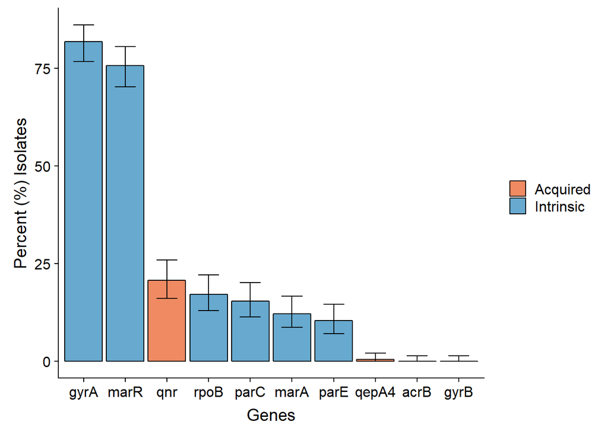

```r
total_mechanisms <- mut_report %>%
  select(-nt_change) %>%
  left_join(acquired_report, by = "id") %>%
  mutate_at(vars(qnrA1,qnrB19,qnrB6,qnrB60,qnrS1,qnrS2,qnrS4),
            funs(as.numeric(.))) %>%
  mutate(qnr = ifelse(rowSums(.[,11:17]) == 0, 0, 1)) %>%
  select(-c(qnrA1,qnrB19,qnrB6,qnrB60,qnrS1,qnrS2,qnrS4)) %>%
  gather(gene, result, -id) %>%
  group_by(gene, result) %>%
  count() %>%
  ungroup() %>%
  mutate(result = ifelse(result == 1, "Present", "Absent")) %>%
  spread(result, n, fill = 0) %>%
  rowwise() %>%
  mutate(Total = Present + Absent,
         Percent = round((Present/Total)*100, 1),
         lwr = round(get_binCI(Present, Total)[1], 1),
         upr = round(get_binCI(Present, Total)[2], 1),
         type = ifelse(gene %in% c("qnr","qepA4"), "Acquired","Intrinsic"))

palette2 <- c("Acquired" = "#ef8a62",
              "Intrinsic" = "#67a9cf")

ggplot(total_mechanisms, aes(reorder(gene, -Percent), Percent, fill = type)) +
  geom_col(color = "black") +
  geom_errorbar(aes(ymin = lwr, ymax = upr),
                width = 0.5) +
  scale_fill_manual(values = palette2) +
  labs(x = "Genes",
       y = "Percent (%) Isolates",
       fill = NULL)
```

## 4.2 Percent isolates with PMQR and/or QRDR mutations in *gyrA*, *gyrB*, *parC* or *parE*

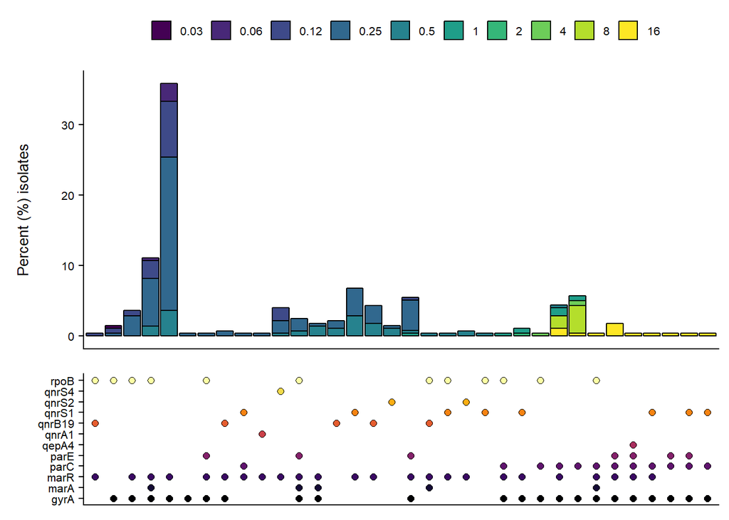

```r
total_report <- mut_report %>%
  left_join(acquired_report, by = "id") %>%
  gather(gene, value, -id) %>%
  mutate(present = ifelse(value == 1, gene, NA),
         ref = 1:n()) %>%
  spread(gene, value) %>%
  group_by(id) %>%
  summarise_all(funs(func_paste)) %>%
  select(-ref) %>%
  left_join(mic_data[c("id","CIP")], by = "id") %>%
  group_by(present,CIP) %>%
  count() %>%
  ungroup() %>%
  rowwise() %>%
  mutate(present = ifelse(present == "", "None", present),
         total = 280,
         percent = round(n/total * 100, 1),
         lwr = round(get_binCI(n, total)[1], 1),
         upr = round(get_binCI(n, total)[2], 1))

genes <- c(names(mut_report), names(acquired_report))
genes <- genes[!genes %in% c("id","nt_change")]

cip_n_plot <- ggplot(total_report, aes(reorder(present, as.numeric(CIP)), percent, fill = factor(CIP)))+
  geom_col(color = "black")+
  labs(y = "Percent (%) isolates")+
  scale_fill_viridis(discrete = TRUE)+
  guides(fill=guide_legend(ncol = 10))+
  theme(axis.text.x = element_blank(),
        axis.ticks.x = element_blank(),
        axis.title.y = element_text(size = 10),
        axis.text.y = element_text(size = 8),
        axis.title.x = element_blank(),
        legend.text = element_text(size = 8),
        legend.title = element_blank(),
        legend.position = "top",
        legend.spacing.x = unit(0.2, "cm"),
        legend.justification = "center")

dot_report <- mut_report %>%
  left_join(acquired_report, by = "id") %>%
  select(-nt_change) %>%
  gather(gene, value, -id) %>%
  mutate(present = ifelse(value == 1, gene, NA),
         ref = 1:n()) %>%
  spread(gene, value) %>%
  group_by(id) %>%
  summarise_all(funs(func_paste)) %>%
  left_join(mic_data[c("id","CIP")], by = "id") %>%
  select(-c(ref, id)) %>%
  ungroup() %>%
  mutate_at(vars(-present, CIP), .funs = as.numeric) %>%
  mutate(none = ifelse(rowSums(.[,genes]) == 0, 1, 0),
         present = ifelse(present == "", "None", present)) %>%
  gather(gene, value, -c(present,CIP)) %>%
  mutate(gene = ifelse(value == 0 & gene != "None", NA, gene),
         value = ifelse(gene == "None" & value == 0, NA, value)) %>%
  na.omit()


mechanism_dot_plot <- ggplot(dot_report, aes(reorder(present, CIP), gene, fill = gene))+
  geom_point(size = 2, pch = 21)+
  scale_fill_viridis(option = "B",
                     discrete = TRUE)+
  guides(fill = FALSE)+
  theme(axis.text.x = element_blank(),
        axis.text.y = element_text(size = 8),
        axis.title = element_blank(),
        axis.ticks.x = element_blank())

plot_grid(cip_n_plot, mechanism_dot_plot, nrow = 2, align = "v", rel_heights = c(3.5/5, 1.5/5))
```

## 4.3 Percent QREC isolates with mutations in intrinsic genes

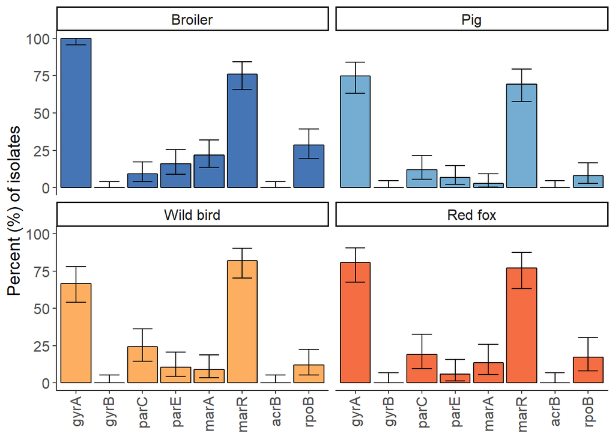

```r
gene_names <- names(mut_report)

gene_names <- gene_names[-c(1,2)]

palette <- c("Broiler" = "#4575b4",
             "Pig" = "#74add1",
             "Red fox" = "#f46d43",
             "Wild bird" = "#fdae61")

mut_report %>%
    left_join(isolate_data, by = "id") %>%
    gather(key, value, gene_names) %>%
    group_by(key, value, species) %>%
    count() %>%
    ungroup() %>%
    mutate(value = if_else(value == 1, "Present", "Absent")) %>%
    spread(value, n, fill = 0) %>%
    rowwise() %>%
    mutate(
      Total = Present + Absent,
      Percent = round(Present / Total * 100, 1),
      lwr = round(get_binCI(Present, Total)[1], 1),
      upr = round(get_binCI(Present, Total)[2], 1)
    ) %>%
    mutate(species = factor(species,
                            levels = c("Broiler","Pig","Wild bird","Red fox"))) %>%
    ggplot(aes(key, Percent, fill = species)) +
    geom_col(color = "black",
             position = position_dodge(1)) +
    geom_errorbar(
      aes(ymin = lwr, ymax = upr),
      width = 0.6,
      position = position_dodge(1)
    ) +
    scale_fill_manual(values = palette) +
    scale_x_discrete(limits = c("gyrA","gyrB","parC","parE","marA","marR","acrB","rpoB")) +
    labs(y = "Percent (%) of isolates") +
    guides(fill = FALSE) +
    theme_classic() +
    theme(
      axis.text.x = element_text(
        angle = 90,
        size = 12,
        hjust = 1,
        vjust = 0.4
      ),
      axis.title.x = element_blank(),
      axis.text.y = element_text(size = 12),
      axis.title.y = element_text(size = 14),
      strip.text = element_text(size = 12)
    ) +
    facet_wrap(~ species)
```

## 4.4 Percent QREC isolates with Qnr genes per species

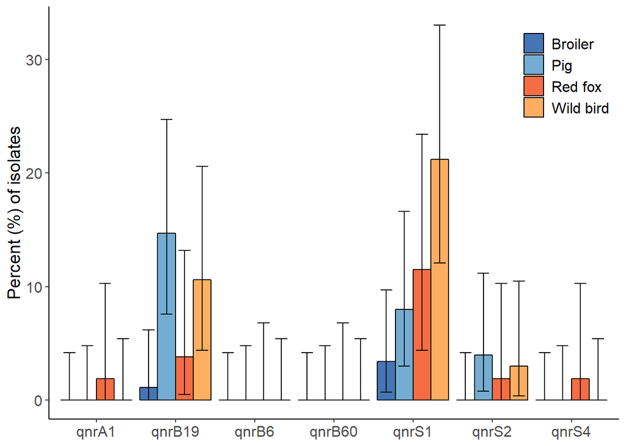

```r
qnr_genes <- c("qnrA1","qnrB19","qnrB6","qnrB60","qnrS1","qnrS2","qnrS4")

acquired_report %>%
    left_join(isolate_data, by = "id") %>%
    gather(key, value, qnr_genes) %>%
    group_by(key, value, species) %>%
    count() %>%
    ungroup() %>%
    mutate(value = if_else(value == 1, "Present", "Absent")) %>%
    spread(value, n, fill = 0) %>%
    rowwise() %>%
    mutate(
      Total = Present + Absent,
      Percent = round(Present / Total * 100, 1),
      lwr = round(get_binCI(Present, Total)[1], 1),
      upr = round(get_binCI(Present, Total)[2], 1)
    ) %>%
    ggplot(aes(key, Percent, fill = species)) +
    geom_col(color = "black",
             position = position_dodge(0.9)) +
    geom_errorbar(
      aes(ymin = lwr, ymax = upr),
      width = 0.6,
      position = position_dodge(0.9)
    ) +
    scale_fill_manual(values = palette) +
    labs(y = "Percent (%) of isolates",
         fill = NULL) +
    theme_classic() +
    theme(
      axis.text = element_text(size = 12),
      axis.title.y = element_text(size = 14),
      legend.text = element_text(size = 12),
      axis.title.x = element_blank(),
      legend.justification = c(0, 1),
      legend.position = c(0.82, 0.97)
    )
```

## 4.5 Total resistance mechanisms per animal species

This figure presents the percent combination of resistance mechanisms per CIP MIC category. The X-axis on the leftmost plot lists all the specific mutations in *gyrA*, *parC* and *parE*, whether *marR* is mutated or not, as well as a summation of all the *qnr* genes and *qepA*. The rightmost plot presents how many isolates are present in the given CIP-MIC group (Y-axis in both plots).

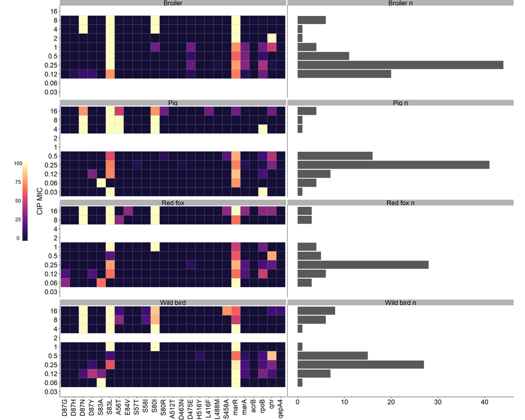

```r
AddCol <- function(df, col_name) {
  # split rows by delimeters
  string_to_proc <- df %>% select(!!col_name) %>%
    unlist() %>% str_split(regex("\\, |\\,"))
  # find unique entries
  unique_strings <- string_to_proc %>%
    unlist() %>% unique()
  # construct names of the new columns
  cols_names <- paste(col_name, unique_strings, sep = "_")
  # construct 0/1-content columns for each unique entry
  cols_content <- sapply(function(i) {
    as.integer(unlist(lapply(function(Z) any(Z %in% unique_strings[i]),
                             X = string_to_proc)))
  }, X = seq_along(unique_strings))
  res <- data.frame(cols_content)
  names(res) <- cols_names
  return(res)
}

total_df <- acquired_report %>%
  left_join(mut_quant[c("gyrA","gyrB","parC","parE","id")], by = "id") %>%
  left_join(mut_report[c("id","marR","marA","acrB","rpoB")], by = "id") %>%
  left_join(isolate_data[c("id", "species")])

col_proc <- c("gyrA","gyrB","parC","parE")

id <- total_df$id

cols_to_add <- sapply(function(i) {AddCol(df = total_df, col_name = col_proc[i])},
                      X = seq_along(col_proc)) %>%
  bind_cols() %>%
  cbind(id) %>%
  gather(key, value, -id) %>%
  filter(grepl("(.*?)_0", key) == FALSE) %>%
  spread(key, value)

total_df2 <- total_df %>%
  select(-c(gyrA, gyrB, parC, parE)) %>%
  left_join(cols_to_add, by = "id") %>%
  select(id, species, everything()) %>%
  mutate_at(vars(qnrA1,qnrB19,qnrB6,qnrB60,qnrS1,qnrS2,qnrS4),
            funs(as.numeric(.))) %>%
  mutate(qnr = ifelse(rowSums(.[,4:10]) == 0, 0, 1)) %>%
  select(-c(qnrA1,qnrB19,qnrB6,qnrB60,qnrS1,qnrS2,qnrS4)) %>%
  left_join(mic_data[c("id","CIP")], by = "id") %>%
  select(-id) %>%
  mutate_at(vars(-species, CIP),
            funs(as.numeric(as.character(.)))) %>%
  group_by(species, CIP) %>%
  summarise_all(funs(sum, n = n())) %>%
  select(-c(qepA4_n,qnr_n,gyrA_D87G_n,gyrA_D87H_n,
            gyrA_D87N_n,gyrA_D87Y_n,gyrA_S83A_n,
            gyrA_S83L_n,parC_A56T_n,parC_E84V_n,
            parC_S57T_n,parC_S58I_n,parC_S80I_n,
            parC_S80R_n,parE_A512T_n,parE_D463N_n,
            parE_D475E_n,parE_H516Y_n,parE_L416F_n,
            parE_L488M_n,parE_S458A_n,marA_n,rpoB_n,
            acrB_n)) %>%
  gather(gene, value, -c(species, CIP, marR_n)) %>%
  rename("n" = marR_n) %>%
  mutate(gene2 = sub("(.*?)_(.*?)_sum", "\\1", gene),
         gene2 = sub("(.*?)_sum", "\\1", gene2),
         gene = sub("(.*?)_(.*?)_sum", "\\2", gene),
         gene = sub("(.*?)_sum", "\\1", gene),
         type = case_when(gene2 == "gyrA" ~ 1,
                          gene2 == "gyrB" ~ 2,
                          gene2 == "parC" ~ 3,
                          gene2 == "parE" ~ 4,
                          gene2 == "marR" ~ 5,
                          gene2 == "marA" ~ 6,
                          gene2 == "mdfA" ~ 7,
                          gene2 == "acrB" ~ 8,
                          gene2 == "rpoB" ~ 9,
                          gene2 == "qnr" ~ 10,
                          gene2 == "qepA4" ~ 11),
         perc = value/n*100)

p1 <- ggplot(total_df2, aes(reorder(gene, type), factor(CIP), fill = perc))+
  geom_tile(color = "grey70")+
  scale_fill_viridis(option = "A",
                     begin = 0.1,
                     guide = guide_colorbar(barheight = 15,
                                            barwidth = 1,
                                            label.position = "left",
                                            label.hjust = 0.5,
                                            label.vjust = 0.3,
                                            ticks = TRUE))+
  theme(axis.text.x = element_text(angle = 90, hjust = 1, vjust = 0.3, size = 18),
        axis.text.y = element_text(size = 18),
        axis.title.x = element_blank(),
        axis.title.y = element_text(size = 20),
        strip.background = element_rect(colour = "black", fill = "grey70"),
        strip.text = element_text(size = 18),
        legend.position = "left",
        legend.title = element_blank(),
        legend.text = element_text(size = 14),
        plot.margin = unit(c(0,0,0,0), "cm"))+
  labs(y = "CIP MIC")+
  facet_wrap(~species, ncol = 1)+
  coord_fixed()

nplot_data <- total_df %>%
  left_join(mic_data[c("id","CIP")], by = "id") %>%
  group_by(species, CIP) %>%
  count() %>%
  ungroup() %>%
  mutate(species = paste0(species, " n"))

p2 <- ggplot(nplot_data, aes(factor(CIP), n))+
  geom_col()+
  theme(axis.title = element_blank(),
        axis.text.y = element_blank(),
        axis.text.x = element_text(size = 18),
        axis.ticks.y = element_blank(),
        strip.text = element_text(size = 18),
        strip.background = element_rect(colour = "black", fill = "grey70"),
        plot.margin = unit(c(0,0,-10,0), "cm"))+
  facet_wrap(~species, ncol = 1)+
  coord_flip()

p1g <- ggplotGrob(p1)
p2g <- ggplotGrob(p2)

g <- cbind(p1g, p2g, size = "first")

grid.arrange(g)
```

## 4.6 Correlation plot

This plot presents the results of a pearson correlation test for each resistance mechanism. A positive correlation is represented in yellow and red spectra, a negative correlation represented as blue and light blue, and no correlation in green.

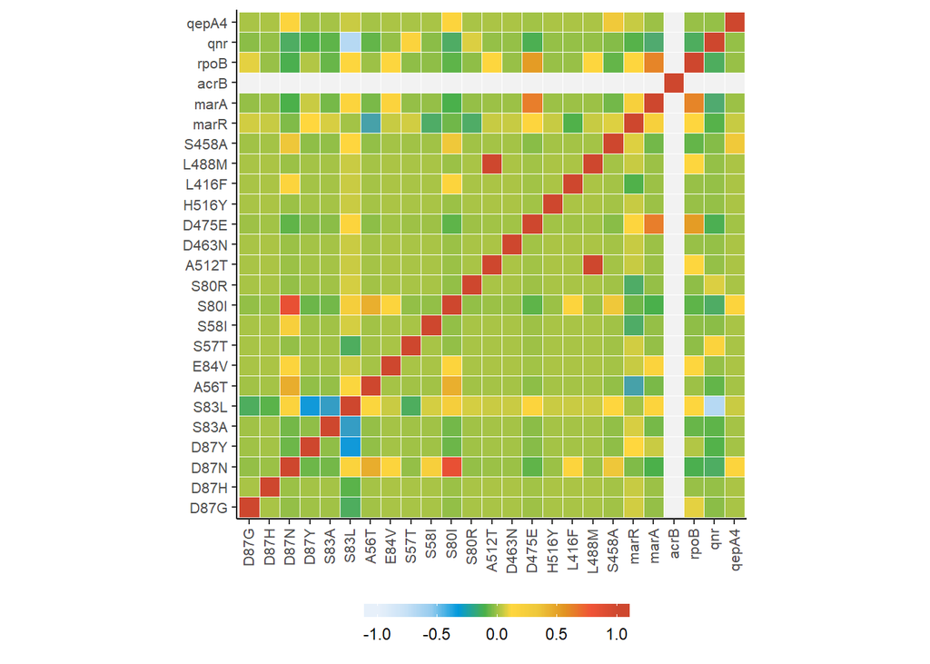

```r
create_corr_matrix <- function(df) {
  df <- df %>%
    as.matrix %>%
    cor %>%
    as.data.frame %>%
    rownames_to_column(var = "var1") %>%
    gather(var2, value, -var1) %>%
    mutate(var1 = gsub("(.*?)_R$", "\\1", var1),
           var2 = gsub("(.*?)_R$", "\\1", var2))
  return(df)
}

total_df <- acquired_report %>%
  left_join(mut_quant[c("gyrA","gyrB","parC","parE","id")], by = "id") %>%
  left_join(mut_report[c("id","marR","marA","acrB","rpoB")], by = "id")

col_proc <- c("gyrA","gyrB","parC","parE")

id <- total_df$id

cols_to_add <- sapply(function(i) {AddCol(df = total_df, col_name = col_proc[i])},
                      X = seq_along(col_proc)) %>%
  bind_cols() %>%
  cbind(id) %>%
  gather(key, value, -id) %>%
  filter(grepl("(.*?)_0", key) == FALSE) %>%
  spread(key, value)

corr_df <- total_df %>%
  select(-c(gyrA, gyrB, parC, parE)) %>%
  left_join(cols_to_add, by = "id") %>%
  select(-id) %>%
  mutate_all(funs(as.numeric)) %>%
  mutate(qnr = ifelse(rowSums(.[,2:8]) == 0, 0, 1)) %>%
  select(-c(qnrA1,qnrB19,qnrB6,qnrB60,qnrS1,qnrS2,qnrS4))

corr_matrix <- create_corr_matrix(corr_df) %>%
    mutate(gene1 = gsub("(.*?)_.+", "\\1", var1),
           gene2 = gsub("(.*?)_.+", "\\1", var2),
           var1 = gsub(".+_(.*?)", "\\1", var1),
           var2 = gsub(".+_(.*?)", "\\1", var2),
           type1 = case_when(gene1 == "gyrA" ~ 1,
                          gene1 == "gyrB" ~ 2,
                          gene1 == "parC" ~ 3,
                          gene1 == "parE" ~ 4,
                          gene1 == "marR" ~ 5,
                          gene1 == "marA" ~ 6,
                          gene1 == "acrB" ~ 7,
                          gene1 == "rpoB" ~ 8,
                          gene1 == "mdfA" ~ 9,
                          gene1 == "qnr" ~ 10,
                          gene1 == "qepA4" ~ 11),
           type2 = case_when(gene2 == "gyrA" ~ 1,
                          gene2 == "gyrB" ~ 2,
                          gene2 == "parC" ~ 3,
                          gene2 == "parE" ~ 4,
                          gene2 == "marR" ~ 5,
                          gene2 == "marA" ~ 6,
                          gene2 == "acrB" ~ 7,
                          gene2 == "rpoB" ~ 8,
                          gene2 == "mdfA" ~ 9,
                          gene2 == "qnr" ~ 10,
                          gene2 == "qepA4" ~ 11))

cols <- c("#e7f0fa","#c9e2f6","#95cbee","#0099dc","#4ab04a",
          "#ffd73e","#eec73a","#e29421","#f05336","#ce472e")

ggplot(corr_matrix, aes(reorder(var1, type1), reorder(var2, type2), fill = value))+
  geom_tile(color = "white")+
  scale_fill_gradientn(colors=cols,
                       na.value="grey95",
                       limits=c(-1, 1),
                       guide=guide_colourbar(ticks=T,nbin=10,
                                             barheight=.5,label=T,
                                             barwidth=10))+
  labs(fill = NULL)+
  theme_classic()+
  theme(axis.text = element_text(size = 8),
        axis.text.x = element_text(angle = 90, hjust = 1, vjust = 0.4),
        axis.title = element_blank(),
        legend.position="bottom",
        legend.justification="center",
        legend.direction="horizontal")+
  coord_fixed()
```

## 4.7 Sequence types per resistance category

This plot presents the percent of isolates in each sequence type group that are resistant to multiple antimicrobials, sorted from least resistant at the top and most resistant at the bottom. The percentage is based on each ST group, and how many isolates in that group.

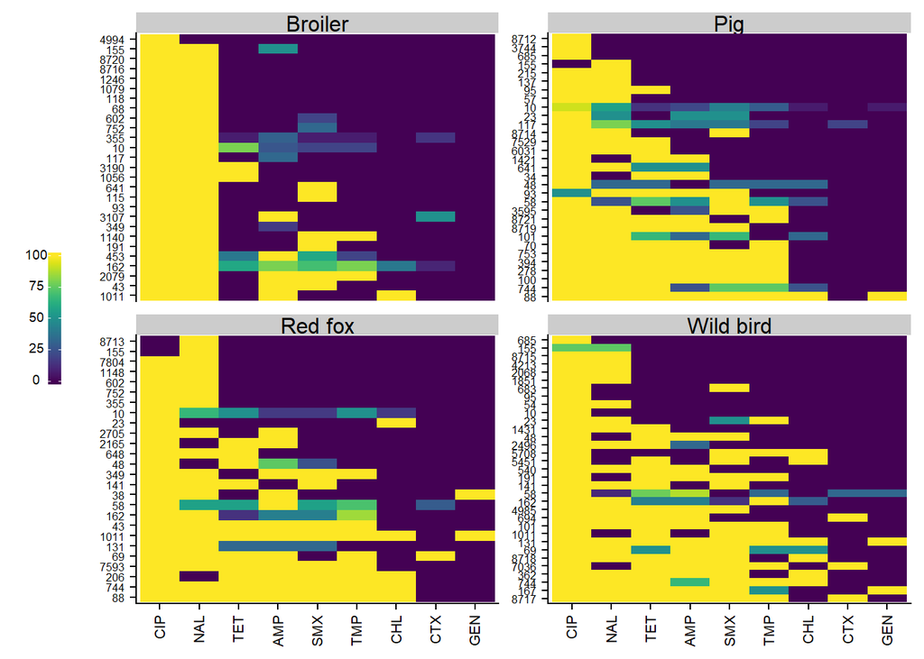

```r
ST_MIC <- mic_data %>%
  left_join(mlst_data[c("id","ST")], by = "id") %>%
  mutate(SMX_R = ifelse(as.numeric(SMX) > 64, 1, 0),
         TMP_R = ifelse(as.numeric(TMP) > 2, 1, 0),
         CIP_R = ifelse(as.numeric(CIP) > 0.06, 1, 0),
         TET_R = ifelse(as.numeric(TET) > 8, 1, 0),
         NAL_R = ifelse(as.numeric(NAL) > 16, 1, 0),
         CTX_R = ifelse(as.numeric(CTX) > 0.25, 1, 0),
         CHL_R = ifelse(as.numeric(CHL) > 16, 1, 0),
         AMP_R = ifelse(as.numeric(AMP) > 8, 1, 0),
         GEN_R = ifelse(as.numeric(GEN) > 2, 1, 0)) %>%
  mutate(NAL_CIP_R = rowSums(.[,c(15,17)]),
         antres = rowSums(.[,13:21])-NAL_CIP_R) %>%
  select(-c(NAL_CIP_R,SMX,TMP,CIP,TET,NAL,CTX,CHL,AMP,GEN)) %>%
  left_join(isolate_data[c("id", "species")], by = "id") %>%
  gather(AB, res, -c(id, antres, ST, species)) %>%
  group_by(AB, ST, res, species) %>%
  count() %>%
  spread(res, n, fill = 0) %>%
  rename("res" = "1",
         "nonres" = "0") %>%
  group_by(AB, ST) %>%
  mutate(p = res/(res+nonres)*100) %>%
  ungroup() %>%
  mutate(AB = gsub("_R", "", AB))


ggplot(ST_MIC, aes(reorder(AB, -p), reorder(ST, -p), fill = p))+
  geom_tile()+
  scale_fill_viridis(guide = guide_colorbar(barheight = 5,
                                            barwidth = 0.5,
                                            label.position = "left",
                                            label.hjust = 0.5,
                                            label.vjust = 0.3,
                                            ticks = TRUE))+
  labs(y = "Antimicrobials")+
  theme(axis.text.y = element_text(size = 6),
        axis.text.x = element_text(angle = 90, hjust = 1, vjust = 0.4, size = 8),
        axis.title.x = element_blank(),
        axis.title.y = element_blank(),
        legend.position = "left",
        legend.title = element_blank(),
        legend.text = element_text(size = 7))+
  facet_wrap(~ species, scales = "free_y", ncol = 2)
```

## 4.8 Phenotypic resistance combinations

This plot presents the various phenotypic resistance combinations present in the isolates, and how many isolates for each animal species in each group.

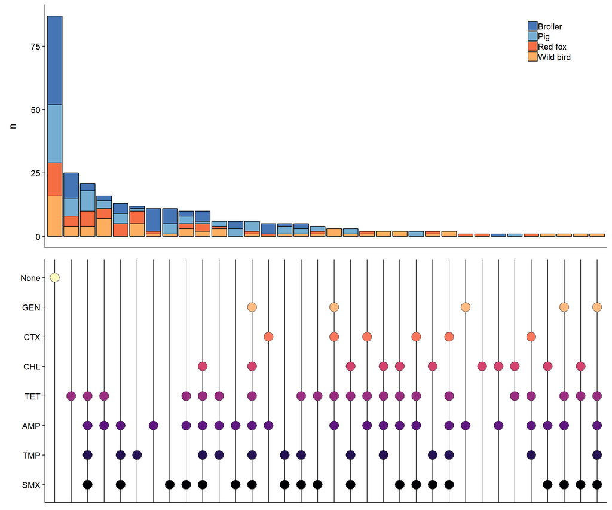

```r
mic_dotplot_data <- mic_data %>%
  mutate(SMX_R = ifelse(SMX > 64, 1, 0),
         TMP_R = ifelse(TMP > 2, 1, 0),
         CIP_R = ifelse(CIP > 0.06, 1, 0),
         TET_R = ifelse(TET > 8, 1, 0),
         NAL_R = ifelse(NAL > 16, 1, 0),
         CTX_R = ifelse(CTX > 0.25, 1, 0),
         CHL_R = ifelse(CHL > 16, 1, 0),
         AMP_R = ifelse(AMP > 8, 1, 0),
         GEN_R = ifelse(GEN > 2, 1, 0)) %>%
  select(contains("_R"), -c(CIP_R, NAL_R)) %>%
  mutate(None = ifelse(rowSums(.) == 0, 1, 0)) %>%
  group_by_all() %>%
  count() %>%
  ungroup() %>%
  mutate(id = 1:n()) %>%
  gather(AM, value, -id, -n) %>%
  mutate(value = ifelse(AM == "None" & value == 0, NA, value),
         value = ifelse(AM != "None" & value == 0, NA, value),
         AM = sub("_R", "", AM)) %>%
  filter(is.na(value) == FALSE) %>%
  mutate(AM = factor(AM, ordered = TRUE, levels = c("SMX","TMP","AMP","TET","CHL","CTX","GEN","None")))


mic_nplot_data <- mic_data %>%
  mutate(SMX_R = ifelse(SMX > 64, 1, 0),
         TMP_R = ifelse(TMP > 2, 1, 0),
         CIP_R = ifelse(CIP > 0.06, 1, 0),
         TET_R = ifelse(TET > 8, 1, 0),
         NAL_R = ifelse(NAL > 16, 1, 0),
         CTX_R = ifelse(CTX > 0.25, 1, 0),
         CHL_R = ifelse(CHL > 16, 1, 0),
         AMP_R = ifelse(AMP > 8, 1, 0),
         GEN_R = ifelse(GEN > 2, 1, 0)) %>%
  select(id, contains("_R"), -c(CIP_R, NAL_R)) %>%
  mutate(None = ifelse(rowSums(.[,2:8]) == 0, 1, 0)) %>%
  left_join(isolate_data[c("id", "species")], by = "id") %>%
  select(-id) %>%
  group_by_all() %>%
  count() %>%
  group_by_at(vars(SMX_R, TMP_R, TET_R, CTX_R, CHL_R, AMP_R, GEN_R)) %>%
  { mutate(ungroup(.), group = group_indices(.)) } %>%
  group_by(group) %>%
  mutate(group_n = sum(n))


mic_dotplot <- ggplot(mic_dotplot_data, aes(reorder(factor(id), -n), AM, fill = AM)) +
  geom_point(size = 6, pch = 21)+
  scale_fill_viridis(option = "A",
                     discrete = TRUE)+
  guides(fill = FALSE)+
  theme(axis.title = element_blank(),
        axis.text.x = element_blank(),
        axis.ticks.x = element_blank(),
        panel.grid.major.x = element_line())

mic_nplot <- ggplot(mic_nplot_data, aes(reorder(factor(group), -group_n), n, fill = species))+
  geom_col(color = "black")+
  scale_fill_manual(values = palette) +
  theme(axis.title.x = element_blank(),
        axis.text.x = element_blank(),
        axis.ticks.x = element_blank(),
        legend.position = c(0.85,0.85),
        legend.title = element_blank())

cowplot::plot_grid(mic_nplot, mic_dotplot, ncol = 1, align = "v")
```

# 5 Phylogeny

## 5.1 Core Genome MLST

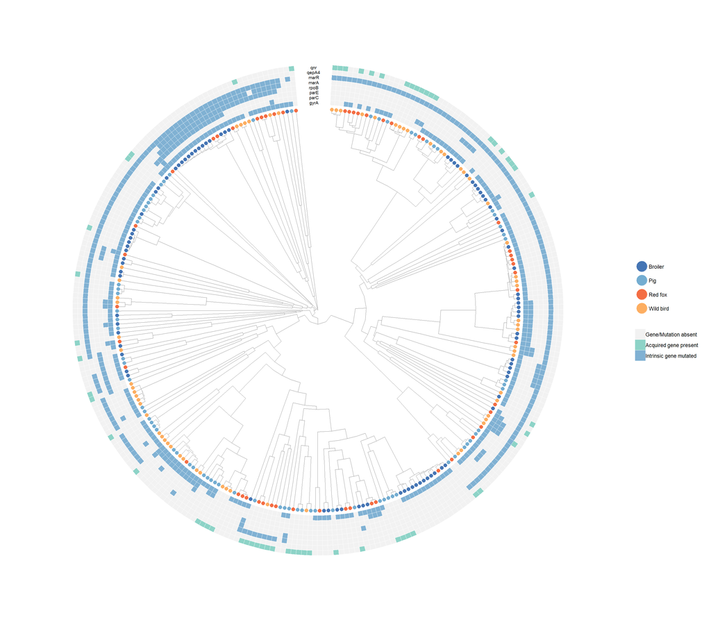

```r
cgMLSTdata <- read.table("../data/cgMLST.txt", sep = "\t", row.names=1, colClasses = "factor", header = T)

palette <- c("Broiler" = "#4575b4",
             "Pig" = "#74add1",
             "Red fox" = "#f46d43",
             "Wild bird" = "#fdae61")

cgMLST_tree <- as.phylo(hclust(daisy(cgMLSTdata, metric="gower")))

test <- hclust(daisy(cgMLSTdata, metric="gower"))

ids <- as.data.frame(cgMLST_tree$tip.label)
names(ids) <- "id"

ids2 <- ids %>%
  left_join(isolate_data[c("id","species")]) %>%
  left_join(mlst_data[c("id", "ST")])

cgMLST_tree$tip.label <- ids2$species

group_info <- split(cgMLST_tree$tip.label, f = cgMLST_tree$tip.label)
cgMLST_tree <- groupOTU(cgMLST_tree, group_info)

cgMLST_tree$tip.label <- ids2$id

p_cgmlst <- ggtree(cgMLST_tree, size = 0.2, color = "#808080", layout = "circular")+
  geom_tippoint(aes(color = group), size = 2.5)+
  labs(color = "Species")+
  scale_color_manual(values = palette)+
  guides(color = guide_legend(override.aes = list(size = 8)))+
  theme(legend.position = "right")

palette3 <- c("1-A" = "#8dd3c7",
              "1-I" = "#80b1d3",
              "0" = "grey95")

qr_genes <- mut_report[c("id","gyrA","parC","parE","rpoB","marA","marR")] %>%
  mutate_at(vars(-id),
            funs(ifelse(. == "1", "1-I", "0")))

ac_genes <- acquired_report %>%
  mutate_at(vars(-id),
            funs(as.numeric)) %>%
  mutate(qnr = ifelse(rowSums(.[,3:9]) != 0 , 1, 0)) %>%
  select(id, qepA4, qnr) %>%
  mutate_at(vars(-id),
            funs(ifelse(. == "1", "1-A", "0")))

total_gene_data <- qr_genes %>%
  left_join(ac_genes, by = "id") %>%
  column_to_rownames("id")

fan_tree <- open_tree(p_cgmlst, 9)

rotated_fan_tree <- rotate_tree(fan_tree, 95)

final_tree <- gheatmap(rotated_fan_tree,
         total_gene_data,
         offset = 0.005,
         width = 0.2,
         colnames_offset_y = 3,
         colnames_position = "top",
         font.size = 2.5) +
  scale_fill_manual(values = palette3,
                    labels = c("Gene/Mutation absent",
                               "Acquired gene present",
                               "Intrinsic gene mutated"))
final_tree
```

```r
alignment <- Biostrings::readAAMultipleAlignment("../data/alignment.fasta")
msaR::msaR(alignment)
```

[interactive chart not shown]